# my_exp_report

Author

佐藤柚菜（2412B10）

## 2. 方法 (Method)

### 装置と材料

実験プログラムはjsPsychを用いて作成し、GitHub Pages上で公開した。参加者は各自のスマートフォンまたはPCのブラウザから参加した。

### 手続き

実験は画面中央への注視点（＋）の500ms提示から開始した。その後、刺激（一桁の数字）が500ms提示され、続いて1500msのブランク画面が提示された。参加者は、提示された数字が「$N$個前と同じか否か」を判断し、一致する場合は画面右側の「一致」ボタンを、不一致の場合は「不一致」ボタンをタップした。本実験では、1つ前と比較する1-Back条件と、2つ前と比較する2-Back条件の2ブロックを実施した。試行間隔（ITI）は1000msに設定し、各試行の反応時間と正答率を記録した。

## 3. 結果 (Results)

[figure not shown]

```
=== 対応のあるt検定結果 ===
```

```
    Paired t-test

data:  data_1back and data_2back
t = 1, df = 1, p-value = 0.5
alternative hypothesis: true mean difference is not equal to 0
95 percent confidence interval:
 -2.926551  3.426551
sample estimates:
mean difference
           0.25
```

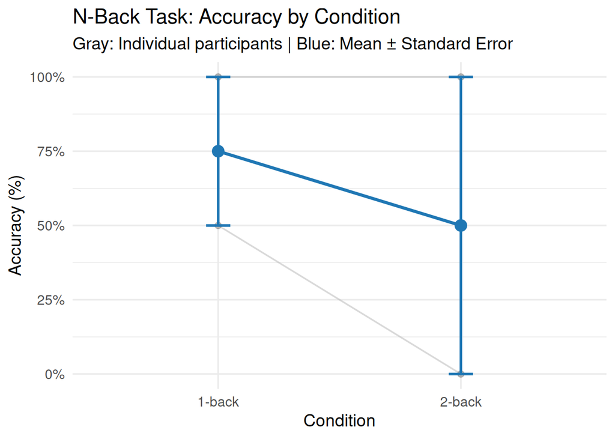

## 5. 引用文献 (References)

Dobbs, Allen R., and Brendan Gail Rule. 1989. “Adult Age Differences in Working Memory.” *Psychology and Aging* 4 (4): 500–503. https://doi.org/10.1037/0882-7974.4.4.500.